# MICB425 Portfolio - Microbial Ecological Genomics: From Genomes to Biomes, Spring 2018

#### Part 4: Alpha-diversity functions in R

We’ve been doing the above calculations by hand, which is a very good exercise to aid in understanding the math behind these estimates. Not surprisingly, these same calculations can be done with R functions. Since we just have a species table, we will use the `vegan` package. You will need to install this package if you have not done so previously.

```r
library(vegan)
```

First, we must remove the unnecesary data columns and transpose the data so that `vegan` reads it as a species table with species as columns and rows as samples (of which you only have 1).

```r
example_data1_diversity =
  example_data1 %>%
  select(name, occurences) %>%
  spread(name, occurences)

example_data1_diversity
```

```
##   bear lion tiger
## 1    1    2     4
```

```r
candy2 = read.table(file="candy2.csv", header=TRUE, sep=",", na.strings=c("NAN", "NA", "."))

candy_diversity =
  candy2 %>%
  select(Name, Count) %>%
  spread(Name, Count)
```

Then we can calculate the Simpson Reciprocal Index using the `diversity` function.

```r
diversity(example_data1_diversity, index="invsimpson")
```

```
## [1] 2.333333
```

```r
diversity(candy_diversity, index="invsimpson")
```

```
## [1] 4.512215
```

And we can calculate the Chao1 richness estimator (and others by default) with the the `specpool` function for extrapolated species richness. This function rounds to the nearest whole number so the value will be slightly different that what you’ve calculated above.

```r
specpool(example_data1_diversity)
```

```
##     Species chao chao.se jack1 jack1.se jack2 boot boot.se n
## All       3    3       0     3        0     3    3       0 1
```

```r
specpool(candy_diversity)
```

```
##     Species chao chao.se jack1 jack1.se jack2 boot boot.se n
## All      13   13       0    13        0    13   13       0 1
```

In Project 1, you will also see functions for calculating alpha-diversity in the `phyloseq` package since we will be working with data in that form.

For your sample:

- What is the Simpson Reciprocal Index using the R function?
- What is the chao1 estimate using the R function?
  - Verify that these values match your previous calculations.

```r
Community_total1 = data.frame(
  number = c(1,2,3,4,5,6,7,8,9,10,11,12,13,14,15,16,17,18,19,20),
  name = c("kiss", "red short string", "red long string", "white spiral", "mike ike", "watermelon", "gummy bear", "marshmallow bear", "lego square", "lego rectangle", "coke", "spider", "big round candy", "skittle", "m&m", "fish", "elongated noodle", "elongated cloud", "elongated oval", "elongated diamond"),
  characteristics = c("teardrop shape", "short string", "long string", "large ellipsoid flat", "rounded rod", "rectangular", "clear bear shape", "opaque bear shape", "large square brick", "small rectangular brick", "coke bottle shape", "spider shape", "sphere", "ellipsoid round", "small elipsoid flat", "fish shape", "short noodle shape", "cloud shape", "oval", "diamond"),
  occurences = c(16,6,10,3,172,1,99,3,3,15,3,6,24,187,243,1,4,3,1,1)
)
```

Part 2: Collector’s Curve

```r
Community_sample1 = data.frame(
  x = c(1,2,3,4,5,6,7,8,9,10,11,12,13,14,15,16,17,18,19,20),
  y = c(0,2,6,7,41,41,57,57,57,62,62,64,70,110,164,164,164,164,165,165)
)
```

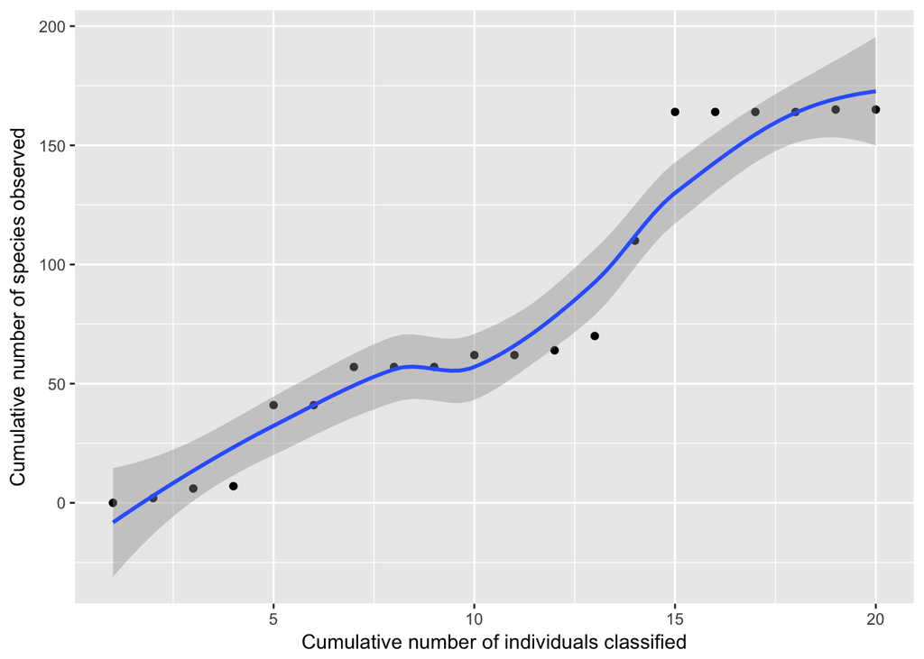

```r
ggplot(Community_sample1, aes(x=x, y=y)) +
  geom_point() +
  geom_smooth() +
  labs(x="Cumulative number of individuals classified", y="Cumulative number of species observed")
```

Part 3: Diversity estimates (alpha diversity) Simpson Reciprocal Index (Community)

```r
species1 = 16/(16+6+10+3+172+1+99+3+3+15+3+6+24+187+243+1+4+3+1+1)
species2 = 6/(16+6+10+3+172+1+99+3+3+15+3+6+24+187+243+1+4+3+1+1)
species3 = 10/(16+6+10+3+172+1+99+3+3+15+3+6+24+187+243+1+4+3+1+1)
species4 = 3/(16+6+10+3+172+1+99+3+3+15+3+6+24+187+243+1+4+3+1+1)
species5 = 172/(16+6+10+3+172+1+99+3+3+15+3+6+24+187+243+1+4+3+1+1)
species6 = 1/(16+6+10+3+172+1+99+3+3+15+3+6+24+187+243+1+4+3+1+1)
species7 = 99/(16+6+10+3+172+1+99+3+3+15+3+6+24+187+243+1+4+3+1+1)
species8 = 3/(16+6+10+3+172+1+99+3+3+15+3+6+24+187+243+1+4+3+1+1)
species9 = 3/(16+6+10+3+172+1+99+3+3+15+3+6+24+187+243+1+4+3+1+1)
species10 = 15/(16+6+10+3+172+1+99+3+3+15+3+6+24+187+243+1+4+3+1+1)
species11 = 3/(16+6+10+3+172+1+99+3+3+15+3+6+24+187+243+1+4+3+1+1)
species12 = 6/(16+6+10+3+172+1+99+3+3+15+3+6+24+187+243+1+4+3+1+1)
species13 = 24/(16+6+10+3+172+1+99+3+3+15+3+6+24+187+243+1+4+3+1+1)
species14 = 187/(16+6+10+3+172+1+99+3+3+15+3+6+24+187+243+1+4+3+1+1)
species15 = 243/(16+6+10+3+172+1+99+3+3+15+3+6+24+187+243+1+4+3+1+1)
species16 = 1/(16+6+10+3+172+1+99+3+3+15+3+6+24+187+243+1+4+3+1+1)
species17 = 4/(16+6+10+3+172+1+99+3+3+15+3+6+24+187+243+1+4+3+1+1)
species18 = 3/(16+6+10+3+172+1+99+3+3+15+3+6+24+187+243+1+4+3+1+1)
species19 = 1/(16+6+10+3+172+1+99+3+3+15+3+6+24+187+243+1+4+3+1+1)
species20 = 1/(16+6+10+3+172+1+99+3+3+15+3+6+24+187+243+1+4+3+1+1)

1 / (species1^2 + species2^2 + species3^2 + species4^2 + species5^2 + species6^2 + species7^2 + species8^2 + species9^2 + species10^2 + species11^2 + species12^2 + species13^2 + species14^2 + species15^2 + species16^2 + species17^2 + species18^2 + species19^2 + species20^2)
```

```
## [1] 4.763291
```

Simpson Reciprocal Index (Sample)

```r
species1 = 0/(0+2+4+1+34+0+16+0+0+5+0+2+6+40+54+0+0+0+1+0)
species2 = 2/(0+2+4+1+34+0+16+0+0+5+0+2+6+40+54+0+0+0+1+0)
species3 = 4/(0+2+4+1+34+0+16+0+0+5+0+2+6+40+54+0+0+0+1+0)
species4 = 1/(0+2+4+1+34+0+16+0+0+5+0+2+6+40+54+0+0+0+1+0)
species5 = 34/(0+2+4+1+34+0+16+0+0+5+0+2+6+40+54+0+0+0+1+0)
species6 = 0/(0+2+4+1+34+0+16+0+0+5+0+2+6+40+54+0+0+0+1+0)
species7 = 16/(0+2+4+1+34+0+16+0+0+5+0+2+6+40+54+0+0+0+1+0)
species8 = 0/(0+2+4+1+34+0+16+0+0+5+0+2+6+40+54+0+0+0+1+0)
species9 = 0/(0+2+4+1+34+0+16+0+0+5+0+2+6+40+54+0+0+0+1+0)
species10 = 5/(0+2+4+1+34+0+16+0+0+5+0+2+6+40+54+0+0+0+1+0)
species11 = 0/(0+2+4+1+34+0+16+0+0+5+0+2+6+40+54+0+0+0+1+0)
species12 = 2/(0+2+4+1+34+0+16+0+0+5+0+2+6+40+54+0+0+0+1+0)
species13 = 6/(0+2+4+1+34+0+16+0+0+5+0+2+6+40+54+0+0+0+1+0)
species14 = 30/(0+2+4+1+34+0+16+0+0+5+0+2+6+40+54+0+0+0+1+0)
species15 = 54/(0+2+4+1+34+0+16+0+0+5+0+2+6+40+54+0+0+0+1+0)
species16 = 0/(0+2+4+1+34+0+16+0+0+5+0+2+6+40+54+0+0+0+1+0)
species17 = 0/(0+2+4+1+34+0+16+0+0+5+0+2+6+40+54+0+0+0+1+0)
species18 = 0/(0+2+4+1+34+0+16+0+0+5+0+2+6+40+54+0+0+0+1+0)
species19 = 1/(0+2+4+1+34+0+16+0+0+5+0+2+6+40+54+0+0+0+1+0)
species20 = 0/(0+2+4+1+34+0+16+0+0+5+0+2+6+40+54+0+0+0+1+0)

1 / (species1^2 + species2^2 + species3^2 + species4^2 + species5^2 + species6^2 + species7^2 + species8^2 + species9^2 + species10^2 + species11^2 + species12^2 + species13^2 + species14^2 + species15^2 + species16^2 + species17^2 + species18^2 + species19^2 + species20^2)
```

```
## [1] 5.122295
```

Chao1 Richness Estimator (Community)

```r
20 + 4^2/(16*2)
```

```
## [1] 20.5
```

Chao1 Richness Estimator (Sample)

```r
11 + 2^2/(9*2)
```

```
## [1] 11.22222
```

Part 4: Alpha-diversity functions in R

```r
library(vegan)

Community_total1_diversity =
  Community_total1 %>%
  select(name, occurences) %>%
  spread(name, occurences)

Community_total1_diversity
```

```
##   big round candy coke elongated cloud elongated diamond elongated noodle
## 1              24    3               3                 1                4
##   elongated oval fish gummy bear kiss lego rectangle lego square m&m
## 1              1    1         99   16             15           3 243
##   marshmallow bear mike ike red long string red short string skittle
## 1                3      172              10                6     187
##   spider watermelon white spiral
## 1      6          1            3
```

```r
diversity(Community_total1_diversity, index="invsimpson")
```

```
## [1] 4.763291
```

```r
specpool(Community_total1_diversity)
```

```
##     Species chao chao.se jack1 jack1.se jack2 boot boot.se n
## All      20   20       0    20        0    20   20       0 1
```

#### Part 5: Concluding activity

If you are stuck on some of these final questions, reading the [Kunin et al. 2010](https://www.ncbi.nlm.nih.gov/pubmed/19725865) and [Lundin et al. 2012](https://www.ncbi.nlm.nih.gov/pubmed/23760801) papers may provide helpful insights.

- How does the measure of diversity depend on the definition of species in your samples? (Answer): Depending on what characteristeristics we choose to group individuals, a species is simply a category that can be bigger or smaller depending on what we choose to put inside it.
- Can you think of alternative ways to cluster or bin your data that might change the observed number of species? (Answer): Change the characteristics that we choose to cluster together as species (such as by color instead of by candy brand).
- How might different sequencing technologies influence observed diversity in a sample? (Answer): Different sequencing types require different post-sequencing quality controls and assembly criterion which introduces different levels of sequencing error, and their corresponding computational biases depending on how the sequences are processed.

### Evidence Worksheet_04

### Learning objectives:

- Discuss the relationship between microbial community structure and metabolic diversity
- Evaluate common methods for studying the diversity of microbial communities
- Recognize basic design elements in metagenomic workflows

### General Questions:

- What were the main questions being asked?

(Answer): What are some of the differences between pathogenic strains of E.coli and non-pathogenic strains on the genome level? What genes and genomic constructs differentiates them and gives certain strains their pathogenic qualities? Are these qualities transient?

- What were the primary methodological approaches used?

(Answer): Basic sequence annotation through annotating ORFs from sequences and BLAST hits were annotated to the ORFs and the genomes were compared after assembly.

- Summarize the main results or findings.

(Answer): They found that the primary genes responsible for pathogenecity is a type III secretion system and its corresponding toxin. Other notable features differentiating between pathogenecity and docility are presence of iron-sequestering systems, adhesins, autotransporters, and recombinases. These exist in pathogenecity islands which disrupts the paradigm that these genes were vertically evolved.

- Do new questions arise from the results?

(Answer): They compared the genetic traits of the pathogenecity islands to determine the likelihood of having been inherited horizontally. If they were to have done the same with the host genomes, wouldn’t they find substantial variation wthin the sequences? If so, how can they determine if something was not a part of the genome inherited vertically if they have no explicit control?

- Were there any specific challenges or advantages in understanding the paper (e.g. did the authors provide sufficient background information to understand experimental logic, were methods explained adequately, were any specific assumptions made, were conclusions justified based on the evidence, were the figures or tables useful and easy to understand)?

(Answer): With the limit of the databse, it is hard to address where the pathogenic islands have come from. The authors did not do a screen through characterized phages or other bacterial species. It is confusing how they laid out figure 3, it is unclear which part of the genome that they are referring to, and how one vertical line can be represented as 100kbp.

### Part 2: Learning objectives:

- Comment on the creative tension between gene loss, duplication and aquisition as it relates to microbial genome evolution.

(Answer): Horizontal gene evolution convolutes what we understand about vertical inheritance since we have no explicit controls of genomes that have never been evolutionarily touched by HGT. But due to this phenomenon, we see transient genes in places where they we would normally expect. To understand evolution, HGT and VGT need to be considered together, despite our best efforts to denoise HGT while studying lineages of genes/organisms.

- Identify common molecular signatures used to infer genomic identity and cohesion.

(Answer): Genomic identity within a genome can be inferred with codon biases, GC content, and relative gene location that may give a clue to whether the genes existed within an organism to an extent long enough to have observably co-evolved with other genes in the organism.

- Differentiate between mobile elements and different modes of gene transfer.

(Answer): Phages, Transposons, Plasmids, Transformation (conjugations), Recombination. Mobile genetic elements include plasmids and phage-packaged DNA. Mobile genetic elements are elements able to replicate themselves and are innately transient, while other types of gene transfer may rely on mechanisms by the cells or phage to be transient.

(Answer): Comparing the two phenotypically distinct strains, we see that their pathogenecity islands are relatively similar with similar genes occuplying locus that are similar as well. They share a number of genes and even for genes that are different, occupy similar locational patterns also. This is evidence that these PAIs originated in some common ancestor and was somehow either horizontally or vertically distributed to these strains. With otherwise similar genomes, these “ecotypes” of bacteria are represent “distinct” forms of their species that occupy an ecological niche within a given environment. These “distinct” forms are highly subjective and in this case, can even fall upon transient properties, allowing the bacteria to gain or lose an “ecotype” based on HGT.

## Writing Assignment 3

[output not shown]

A clear and working concept of microbial species is important for characterization of future unexplored microbial domains, and to push our understanding of the limits of the microbial genome. As important as HGT is in determining the community composition of microbes, the speed of technological and methodological progress has always hindered the ability to resolve HGT relative to VGT. Although we still do not collectively have a flawless working concept of microbial species; through many iterations, we have determined a number of things that the concept is not. We learned early on that microbial species cannot be defined through phenotypic empiricism alone. We also learned that it cannot be fully represented as simply a number of similar genomes. More specifically, not even a number of carefully selected similar sequences in a cluster. With all evidence pointing towards HGT as a major counterbalance to selection pressures, it’s about time we learned that the microbial species concept is not complete without consideration for the horizontal gene transfer phenomenon.

References:

1. Welch RA, Burland V, Plunkett III G, et al. 2002. Extensive mosaic structure revealed by the complete genome sequence of uropathogenic Escherichia coli. PNAS 99:17020-17024.
2. Sogin ML, Morrison HG, Huber JA, et al. 2006. Microbial diversity in the deep sea and the underexplored “rare biosphere”. PNAS 103:12115-12120.
3. Kulin V, Engelbrektson A, Ochman H, Hugenholtz P. 2010. Wrinkes in the rare biosphere: pyrosequencing can lead to artificial inflation of diversity estimates. Env Micb 12:118-123.
4. Callahan BJ, McMurdie PJ, Holmes SP. 2017. Exact sequence variants should replace operational taxonomic units in marker-gene data analysis. ISME J 11:2639-2643.
5. Falkowski PG, Fenchel T, Delong EF. 2008. The Microbial Engines That Drive Earth’s Biological Cycles. Science 320:1034-1038.

## Project 1

(See included project_1.pdf with supplementary materials in current directory)

# Module 4

- Project_2
  - Completion status:
  - Comments:

## Project 2

(See included project_2.pdf with supplementary materials in current directory)